# Statistiques Inférentielles: Tests d’hypothèses

## Illustration sur des données simulées

### Question 1: Test de comparaison de la moyenne d’un échantillon à une moyenne théorique (one sample t-test)

```r
# chargement du fichier
sample <- read.table('../data/td3ex1_100.dat', header = F, dec= '.')
# calcul de la moyenne de l'echantillon
mean_sample = mean(sample$V1)
print(mean_sample)
```

```
[1] 1.55
```

##### Hypothèses

Soit $X \sim N(\mu, \sigma)$. On observe $(X_1,\cdots, X_n)$ un échantillon aléatoire i.i.d. de taille $n$  
L’hypothèse nulle $H_0$ est $\mu = 1.5$ vs $H_1$ $\mu \neq 1.5$ (hypothèse alternative bilatérale).

On fixe le niveau de signification ou risque de première espèce $\alpha = 0.05$. $\alpha$ correspond à la probabilité de rejeter $H_0$ sachant que $H_0$ est vraie.

##### Statistique de test

En considérant $H_0$ vraie on a:
$$\hat{\mu} =
\frac{\frac{1}{n}\sum_{i=1}^{n}X_i -
1.5}{{\sqrt{\frac{s^2}{n}}}}$$
avec $s^2$ l’estimateur sans biais de la variance de $X$ La statistique $\hat{\mu}$ suit sous $H_0$ une loi de Student à $n-1$ degré de liberté.

##### Probabilité critique ou P value

La p value notée $p$ correspond à probabilité d’observer un évènement aussi extrême sachant que $H_0$ est vraie. si $p < \alpha$ alors on rejette $H_0$.

```r
one_sample_t_test <-function(path_table, mu_HO, alpha=0.95){

  # import de la table
  sample <- read.table(path_table, header = F, dec= '.')
  # calcul de la moyenne de l'echantillon
  mean_sample <- mean(sample$V1)
  cat(" La moyenne en substance active de l'échantillon est de:", mean_sample)
  # test de Student sur un échantillon
  result <-t.test(sample$V1, mu=mu_HO,conf.level = alpha)
  if (result$p.value < (1-alpha)){
    cat("\n La p value associée au test est", result$p.value,"on rejette HO")
  }
  else
    cat("\n La p value associée au test est", result$p.value,"on ne rejette PAS HO")
}
```

```r
mu_H0 <- 1.5
```

##### Test de $H_0$ sur un échantillon de taille 100

```r
one_sample_t_test(path_table = '../data/td3ex1_100.dat',mu_H0)
```

```
 La moyenne en substance active de l'échantillon est de: 1.55
 La p value associée au test est 0.3334519 on ne rejette PAS HO
```

##### Test de $H_0$ sur un échantillon de taille 1000

```r
one_sample_t_test(path_table = '../data/td3ex1_1000.dat', mu_H0)
```

```
 La moyenne en substance active de l'échantillon est de: 1.55
 La p value associée au test est 0.002074402 on rejette HO
```

## Test de comparaison d’échantillons (two sample t-test)

L’hypothèse nulle, $H_0$ est $\mu_{long} \leq \mu_{stand}$ et $H_1$, $\mu_{long} > \mu_{stand}$

Les deux échantillons sont issus d’une loi gaussienne et sont indépendants. Leurs variances ne sont pas connues. On utilise la statistique de test suivante:
$$\frac{\bar{X_1} -
\bar{X_2}}{\sqrt{\frac{s_1^2}{N_1} + \frac{s_2^2}{N_2}}}$$
Sous $H_0$ la statistique de test suit une loi de Student dont le nombre de degré de liberté $\nu$ est une fonction complexe des deux échantillons. (Voir https://search.r-project.org/CRAN/refmans/DanielBiostatistics10th/html/Gosset_Welch.html et les références contenues pour une explication détaillée)

Le fichier n’est a priori pas disponible sur Moodle nous allons simuler les données en nous inspirant de l’énoncé. On sait que la durée de vie d’une batterie standard (et longlife) suit une loi normale. La durée moyenne d’une batterie standard est estimée à 120 heures. Nous pouvons donc simuler un échantillon gaussien de taille $n_{standart}=1000$ et d’écart type $\sigma_{standard}=20$. Pour simuler l’échantillon des batteries long life utilison un échantillon de taille $n_long$=500 et une distribution gaussienne de moyenne $\mu_long=130$ et d’écart type $\sigma_{standard}=30$

> Remarque: afin de nous assurer d’avoir des résultats cohérents on fixe la graine du générateur de nombre aléatoire de R en utilisant l’instruction setseed(123).

```r
set.seed(123)
standard = rnorm(1000, 120, 20)
longlife = rnorm(500, 130, 30)
result = t.test(longlife,standard, alternative="greater")
print(result)
```

```
    Welch Two Sample t-test

data:  longlife and standard
t = 7.1068, df = 726.94, p-value = 1.42e-12
alternative hypothesis: true difference in means is greater than 0
95 percent confidence interval:
 8.038624      Inf
sample estimates:
mean of x mean of y
 130.7860  120.3226
```

```r
set.seed(123)
standard = rnorm(1000, 120, 20)
longlife = rnorm(500, 120, 30)
result = t.test(longlife, mean=120 + 12, alternative="greater")
print(result)
```

```
    One Sample t-test

data:  longlife
t = 90.677, df = 499, p-value < 2.2e-16
alternative hypothesis: true mean is greater than 0
95 percent confidence interval:
 118.5909      Inf
sample estimates:
mean of x
  120.786
```

## Application sur des données réelles

```r
# Chargement des données
data("PlantGrowth")
summary(PlantGrowth)
```

```
     weight       group
 Min.   :3.590   ctrl:10
 1st Qu.:4.550   trt1:10
 Median :5.155   trt2:10
 Mean   :5.073
 3rd Qu.:5.530
 Max.   :6.310
```

### Description de données

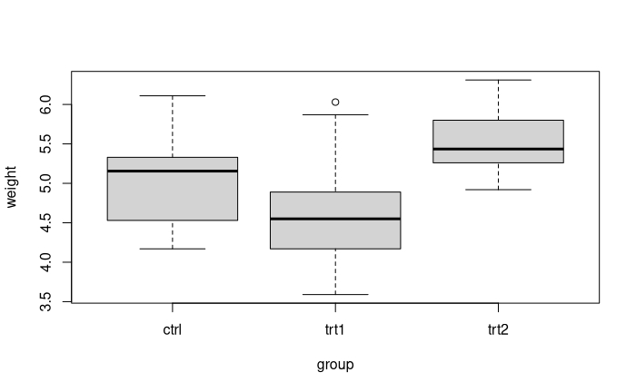

```r
boxplot(weight ~ group, data=PlantGrowth)
```

```r
# Mediane differente par sous-groupe et deux sous groupes semblent asymétriques (attention peu de données)
# Estimation ponctuelle des poids moyen par sous-groupe
mean_by_group <- aggregate(PlantGrowth$weight, list(PlantGrowth$group), FUN=mean)
print(mean_by_group)
```

| Group.1 | x |
| --- | --- |
| ctrl | 5.032 |
| trt1 | 4.661 |
| trt2 | 5.526 |

### Estimation par intervalle de confiance

# Calcul de moments de la distribution

```r
library(e1071)
skewness_by_group <- aggregate(PlantGrowth$weight, list(PlantGrowth$group), FUN=skewness)
kurtosis_by_group <- aggregate(PlantGrowth$weight, list(PlantGrowth$group), FUN=kurtosis)
print(skewness_by_group)
```

| Group.1 | x |
| --- | --- |
| ctrl | 0.2311020 |
| trt1 | 0.4744580 |
| trt2 | 0.4847153 |

```r
print(kurtosis_by_group)
```

| Group.1 | x |
| --- | --- |
| ctrl | -1.116799 |
| trt1 | -1.104735 |
| trt2 | -1.160361 |

```r
for (gr in unique(PlantGrowth$group)){
conf_int <- t.test(PlantGrowth[PlantGrowth$group == gr, 1])$conf.int
print(conf_int)
}
```

[output not shown]

### Test d’hypothèse

```r
for (gr in unique(PlantGrowth$group)){
df <- PlantGrowth[PlantGrowth$group != gr,]
res <- t.test(weight ~ group, data=df)
print(res)
}
```

```
    Welch Two Sample t-test

data:  weight by group
t = -3.0101, df = 14.104, p-value = 0.009298
alternative hypothesis: true difference in means between group trt1 and group trt2 is not equal to 0
95 percent confidence interval:
 -1.4809144 -0.2490856
sample estimates:
mean in group trt1 mean in group trt2
             4.661              5.526


    Welch Two Sample t-test

data:  weight by group
t = -2.134, df = 16.786, p-value = 0.0479
alternative hypothesis: true difference in means between group ctrl and group trt2 is not equal to 0
95 percent confidence interval:
 -0.98287213 -0.00512787
sample estimates:
mean in group ctrl mean in group trt2
             5.032              5.526


    Welch Two Sample t-test

data:  weight by group
t = 1.1913, df = 16.524, p-value = 0.2504
alternative hypothesis: true difference in means between group ctrl and group trt1 is not equal to 0
95 percent confidence interval:
 -0.2875162  1.0295162
sample estimates:
mean in group ctrl mean in group trt1
             5.032              4.661
```

Une ressource interessante sur le même dataset https://www.datanovia.com/en/blog/how-to-perform-t-test-for-multiple-groups-in-r/ La pratique courante est de realiser une ANOVA (qui indique si des différences statistiques existent entre les moyenne des différents groupes puis d’effectuer des tests dits post hoc (t test) en corrigeant pour le nombre de test effectués p.ex. méthode de Bonferonni qui consiste à diviser le niveau de risque $\alpha$ initial par le nombre de tests)

```r
pwc <- PlantGrowth %>%
  pairwise_t_test(weight ~ group, p.adjust.method = "bonferroni")
print(pwc)
```

[output not shown]